# Medical Distribution Business Analysis - Non-Pharmaceuticals Focus

Hospital Consumption Data Analysis (Excluding Pharmaceuticals) - 13 Month Study

Medical Distribution Business Analysis

2025-06-12

🚫 **PHARMACEUTICALS EXCLUDED** 🚫  
This analysis focuses on NON-PHARMACEUTICAL opportunities only  
Excluded: 2,673 pharmaceutical records (558,570 units - 64.8% of total volume)

# 1 Executive Summary

**Analysis Scope:** Non-Pharmaceutical Categories Only  
**Categories Analyzed:** Anaesthesia, Cardiology, Dermatology, Gastroenterology, General/Consumables, Miscellaneous, Ortho, Radiology, Respiratory, Surgical, Urology, Wound Care  
**Market Focus:** Medical supplies, surgical equipment, consumables, and specialized healthcare products

## 1.1 Key Performance Indicators

304,056

Non-Pharma Units Consumed

1007

Unique Non-Pharma Products

66

Non-Pharma Vendors

12

Medical Categories

## 1.2 Strategic Opportunities (Non-Pharmaceutical Focus)

**Why Focus on Non-Pharmaceuticals?**

- **🎯 Less Competition:** Fewer large distributors dominate non-pharma medical supplies
- **💰 Higher Margins:** Specialized medical equipment and supplies often have better profit margins
- **🤝 Relationship Building:** Direct relationships with medical departments vs. pharmacy procurement
- **📈 Growth Potential:** Surgical and specialized equipment markets are rapidly expanding
- **⚡ Faster Entry:** Fewer regulatory barriers compared to pharmaceutical distribution

**Immediate Non-Pharma Opportunities:**

- **Surgical Supplies:** High-value, complex procurement needs
- **Medical Consumables:** Steady demand, predictable ordering patterns
- **Specialized Equipment:** Ortho, cardiology, radiology supplies
- **Wound Care & Respiratory:** Growing market segments

# 2 Market Analysis (Non-Pharmaceutical)

## 2.1 ABC Classification Analysis

### 2.1.1 What is ABC Analysis for Medical Supplies?

#### 📊 ABC Analysis for Non-Pharmaceutical Medical Distribution

**ABC Analysis** for medical supplies helps identify which non-pharmaceutical products drive the most volume and revenue opportunity:

- **Class A (High Priority):** High-volume medical consumables, surgical supplies, and equipment that represent **80% of non-pharma consumption**. These include examination gloves, syringes, surgical instruments, and monitoring equipment.
- **Class B (Medium Priority):** Specialized medical devices and supplies representing **15% of consumption**. These include category-specific instruments, diagnostic supplies, and periodic replacement items.
- **Class C (Low Priority):** Niche medical supplies and equipment representing **5% of consumption**. These include specialized tools, rarely-used equipment, and emergency-only supplies.

**Non-Pharmaceutical Distribution Advantages:**

- 🎯 **Direct Department Sales:** Sell directly to surgery, radiology, orthopedics departments
- 💰 **Value-Added Services:** Equipment training, maintenance, custom kitting
- 📈 **Sticky Relationships:** Equipment compatibility creates vendor loyalty
- ⚡ **Faster Decision Making:** Department heads vs. pharmacy committees

ABC Classification Summary - Non-Pharmaceutical Products Only

| ABC_Class | Items | Total_Quantity | Percentage_of_Volume |
| --- | --- | --- | --- |
| A | 37 | 241,890 | 79.554424 |
| B | 120 | 46,905 | 15.426435 |
| C | 850 | 15,261 | 5.019141 |

### 2.1.2 High-Priority Non-Pharmaceutical Items (Class A)

| ITEM_NAME | CATEGORY | Total_Quantity | Transaction_Count | Percentage_of_Total |
| --- | --- | --- | --- | --- |
| EXAMINATION GLOVES | Surgical | 81,393 | 13 | 26.77 |
| POCT GLUCOSPOT STRIPS | Radiology | 23,000 | 7 | 7.56 |
| POCT LANCET ROUND | Radiology | 21,040 | 8 | 6.92 |
| PARAID-650 | Miscellaneous | 11,250 | 7 | 3.7 |
| ECG ELECTRODES | Radiology | 8,161 | 9 | 2.68 |
| CALCEL -D3 | Miscellaneous | 7,350 | 6 | 2.42 |
| RAPPIN-DSR CAPS | Ortho | 6,200 | 6 | 2.04 |
| DISPOVAN NEEDLE 18 G | General/Consumables | 5,700 | 10 | 1.87 |
| T3-LC | Miscellaneous | 3,940 | 2 | 1.3 |
| MEDIGRIP IV FIX | Miscellaneous | 3,929 | 8 | 1.29 |

[output cut: 27 more lines]

**🎯 Strategic Focus: Class A Items**

These items represent approximately 80% of your total non-pharmaceutical consumption volume. Prioritizing these for inventory management, supplier negotiation, and sales efforts will yield the most significant impact.

- Ensure high availability and optimal stock levels.
- Negotiate favorable terms with suppliers due to high volume.
- Target hospital departments that heavily utilize these specific items.

### 2.1.3 Medium-Priority Non-Pharmaceutical Items (Class B)

| ITEM_NAME | CATEGORY | Total_Quantity | Transaction_Count | Percentage_of_Total |
| --- | --- | --- | --- | --- |
| ATORIX -90 | Miscellaneous | 1,500 | 2 | 0.49 |
| UNDERPADS ADULT | General/Consumables | 1,271 | 8 | 0.42 |
| CELBACT 1GM | Radiology | 1,184 | 2 | 0.39 |
| KARE MED WET WIPES ADULT | Miscellaneous | 1,170 | 6 | 0.38 |
| LOBUN FORTE | Miscellaneous | 1,050 | 6 | 0.35 |
| KEPDOX CV325 | Miscellaneous | 1,000 | 2 | 0.33 |
| DILNIP T | Miscellaneous | 900 | 6 | 0.3 |
| ESMOWAVE-DSR | Miscellaneous | 900 | 1 | 0.3 |
| WET WIPES (ROMSONS) | Miscellaneous | 894 | 5 | 0.29 |
| XIMOREN 500 | Miscellaneous | 820 | 4 | 0.27 |

[output cut: 110 more lines]

**⚙️ Managing Class B Items**

Class B items typically account for the next 15% of consumption volume. While not as critical as Class A, they are still significant.

- Maintain standard inventory controls and review stock levels periodically.
- Explore opportunities for consolidating suppliers if multiple vendors provide similar Class B items.

### 2.1.4 Low-Priority Non-Pharmaceutical Items (Class C)

| ITEM_NAME | CATEGORY | Total_Quantity | Transaction_Count | Percentage_of_Total |
| --- | --- | --- | --- | --- |
| GLUCONORM G1 FORTE | Miscellaneous | 150.0 | 2 | 0.05 |
| ISTAMET-50/500 | Miscellaneous | 150.0 | 2 | 0.05 |
| SOMPRAZ D 40 | Miscellaneous | 150.0 | 1 | 0.05 |
| DEPIN-5MG CAP | Ortho | 140.0 | 3 | 0.05 |
| VENTILATOR CIRCUIT ADULT | Respiratory | 137.0 | 13 | 0.05 |
| DYNACREPE 6" (15 CM X 4 M) | Miscellaneous | 136.0 | 3 | 0.04 |
| GUEDAL AIRWAYS NO. 2 (ROMSONS) | Miscellaneous | 131.0 | 4 | 0.04 |
| TEICOBIOTIC 400 | Miscellaneous | 131.0 | 6 | 0.04 |
| MEROMAC 1GM | Miscellaneous | 130.0 | 3 | 0.04 |
| PANTOCID IT | Miscellaneous | 130.0 | 3 | 0.04 |

[output cut: 840 more lines]

**📦 Handling Class C Items**

Class C items make up the bulk of your unique product count but only a small fraction (around 5%) of total consumption volume.

- Implement simplified inventory controls; consider ordering on demand or in larger, less frequent batches.
- Evaluate if all Class C items are essential or if some can be discontinued or substituted.

**Understanding ABC Classification Tables:**

- **Class A:** Vital few items, typically ~80% of volume. High management priority.
- **Class B:** Intermediate items, typically next ~15% of volume. Moderate management.
- **Class C:** Trivial many items, typically last ~5% of volume. Simpler controls.

The tables above list all items within each respective class, sorted by their consumption quantity. This allows for detailed review and targeted strategies for each segment of your non-pharmaceutical inventory.

### 2.1.5 Non-Pharmaceutical ABC Visualization

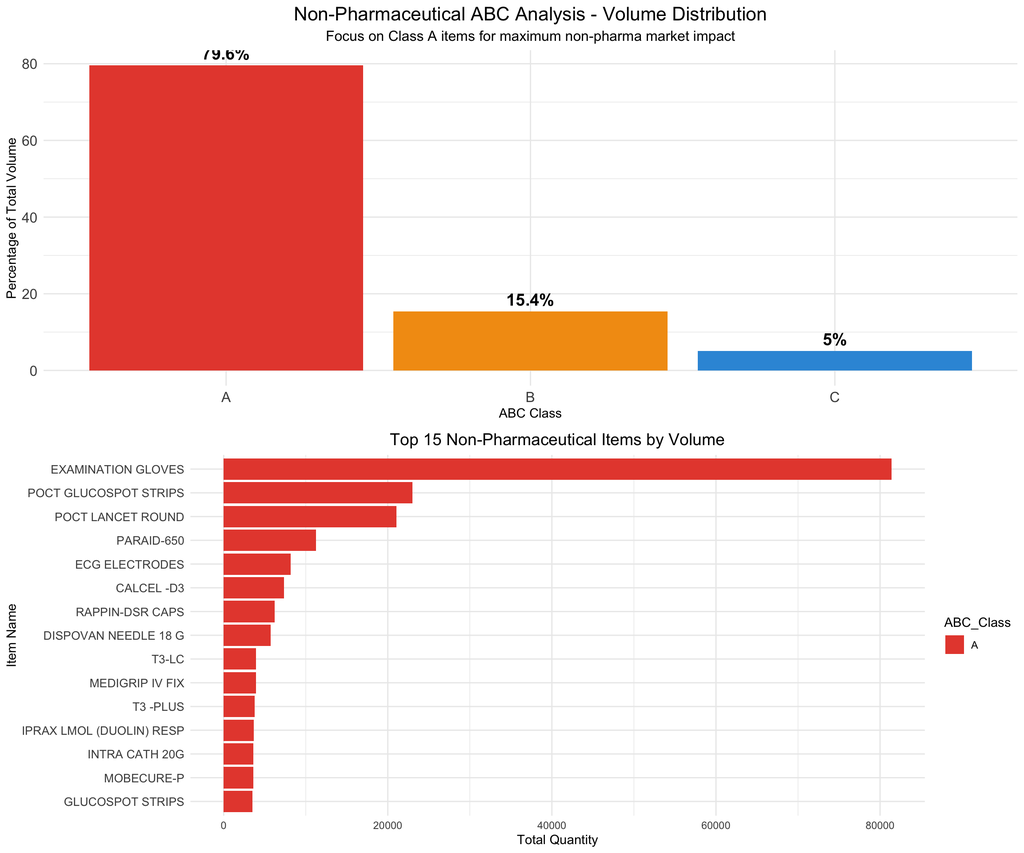

## 2.2 Non-Pharmaceutical ABC Analysis Summary

Detailed Non-Pharmaceutical ABC Analysis

| ABC_Class | Number_of_Items | Total_Volume | Avg_Volume_per_Item | Min_Volume | Max_Volume | Percentage_of_Items | Percentage_of_Volume |
| --- | --- | --- | --- | --- | --- | --- | --- |
| A | 37 | 241,890 | 6,538 | 1,536 | 81,393 | 3.7% | 79.6% |
| B | 120 | 46,905 | 391 | 150 | 1,500 | 11.9% | 15.4% |
| C | 850 | 15,261 | 18 | 1 | 150 | 84.4% | 5% |

#### 🎯 Non-Pharmaceutical Market Opportunities

**Focused Market Intelligence:**

- 📊 **Class A Focus:** Only 37 non-pharma items (3.7% of products) drive 79.6% of total non-pharmaceutical consumption
- 🥇 **Top Opportunity:** “EXAMINATION GLOVES” represents 81,393 units (26.77% of non-pharma volume)
- 💡 **Strategic Advantage:** Non-pharma market is less saturated than pharmaceutical distribution

**Non-Pharmaceutical Distribution Strategy:**

- 🎯 **Department-Specific Approach:** Target surgery, radiology, orthopedics, cardiology departments directly
- 💰 **Value-Added Services:** Offer equipment training, maintenance contracts, custom supply kits
- 📈 **Relationship Leverage:** Equipment compatibility creates switching costs and vendor loyalty
- ⚡ **Faster Sales Cycles:** Department managers make quicker decisions than pharmacy committees

**Operational Focus Areas:**

- **Class A (High-Volume Consumables):** Examination gloves, syringes, monitoring supplies - daily delivery, safety stock
- **Class B (Specialized Equipment):** Surgical instruments, diagnostic devices - weekly reviews, just-in-time delivery
- **Class C (Niche Supplies):** Emergency equipment, rare instruments - quarterly reviews, direct-from-manufacturer

# 3 Category Performance Analysis (Non-Pharmaceutical)

[output not shown]

| CATEGORY | Total_Transactions | Total_Quantity | Unique_Items | Unique_Vendors | Avg_Transaction_Size | Percentage_of_Total | Market_Priority | Business_Opportunity |
| --- | --- | --- | --- | --- | --- | --- | --- | --- |
| Miscellaneous | 1142 | 111,132 | 531 | 52 | 97.3 | 36.5% | High Priority | Major Market |
| Surgical | 107 | 91,581 | 39 | 10 | 855.9 | 30.1% | High Priority | Major Market |
| Radiology | 78 | 57,555 | 31 | 10 | 737.9 | 18.9% | Medium Priority | Major Market |
| Ortho | 278 | 12,990 | 181 | 19 | 46.7 | 4.3% | Low Priority | Niche Market |
| General/Consumables | 95 | 12,609 | 28 | 8 | 132.7 | 4.1% | Low Priority | Niche Market |
| Dermatology | 137 | 7,917 | 66 | 12 | 57.8 | 2.6% | Low Priority | Niche Market |
| Respiratory | 94 | 4,127 | 24 | 8 | 43.9 | 1.4% | Low Priority | Niche Market |
| Wound Care | 47 | 3,333 | 18 | 4 | 70.9 | 1.1% | Low Priority | Niche Market |
| Urology | 64 | 2,154 | 24 | 5 | 33.7 | 0.7% | Low Priority | Niche Market |
| Gastroenterology | 19 | 483 | 8 | 7 | 25.4 | 0.2% | Low Priority | Niche Market |

[output cut: 2 more lines]

**🏥 Non-Pharmaceutical Category Insights:**  
**High-Volume Categories:** Focus on categories with >10% market share for immediate impact  
**Specialized Markets:** Smaller categories often have higher margins and less competition  
**Vendor Fragmentation:** Categories with many vendors offer consolidation opportunities

## 3.1 Non-Pharmaceutical Category Visualization

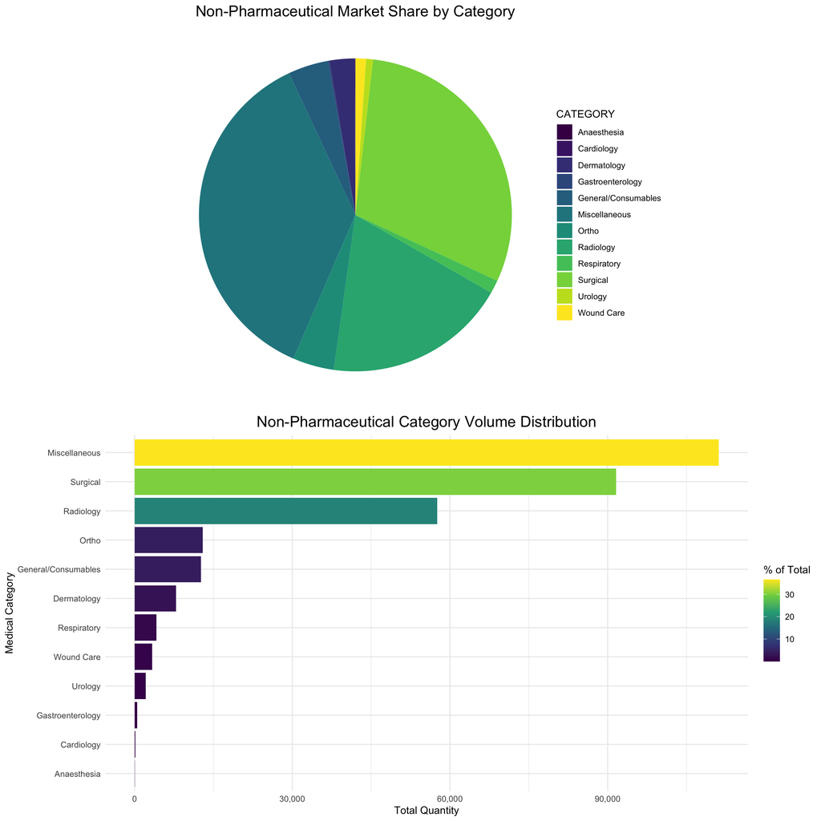

# 4 Vendor Analysis (Non-Pharmaceutical)

Top 15 Non-Pharmaceutical Vendors by Volume

| VENDOR | Total_Transactions | Total_Quantity | Unique_Items | Categories_Served | Avg_Transaction_Size | Market_Share | Vendor_Type |
| --- | --- | --- | --- | --- | --- | --- | --- |
| R&R SURGICALS | 838 | 181,761.0 | 342 | 12 | 216.9 | 59.78 | Major Non-Pharma Supplier |
| V K MEDICALS | 95 | 52,482.0 | 38 | 4 | 552.4 | 17.26 | Major Non-Pharma Supplier |
| LAALITHYAM HOSPITALS PVT LTD | 255 | 24,539.0 | 167 | 10 | 96.2 | 8.07 | Significant Non-Pharma Supplier |
| KRISHNA PHARMACEUTICAL DISTRIBUTORS | 282 | 11,440.5 | 138 | 9 | 40.6 | 3.76 | Regular Non-Pharma Supplier |
| SUMAN AGENCIES HYD PRIVATE LIMITED | 44 | 8,651.5 | 35 | 4 | 196.6 | 2.85 | Regular Non-Pharma Supplier |
| ARKAS PHARMA PRIVATE LIMITED | 10 | 3,800.0 | 7 | 1 | 380.0 | 1.25 | Regular Non-Pharma Supplier |
| DELIGHT BIO PHARMA PVT LTD | 8 | 3,580.0 | 6 | 1 | 447.5 | 1.18 | Regular Non-Pharma Supplier |
| HEALTH PHARMA | 95 | 3,028.0 | 51 | 6 | 31.9 | 1.00 | Small Non-Pharma Supplier |
| KUMAR MEDINEEDS | 8 | 2,836.0 | 2 | 1 | 354.5 | 0.93 | Small Non-Pharma Supplier |
| SS PHARMA | 2 | 2,700.0 | 2 | 1 | 1350.0 | 0.89 | Small Non-Pharma Supplier |
| EROTAS ASSOCITES | 13 | 1,513.0 | 6 | 1 | 116.4 | 0.50 | Small Non-Pharma Supplier |
| KODANDAPANI MEDICALS | 4 | 1,355.0 | 3 | 1 | 338.8 | 0.45 | Small Non-Pharma Supplier |
| SURYA TECHNO MEDICALS | 38 | 1,326.0 | 37 | 9 | 34.9 | 0.44 | Small Non-Pharma Supplier |
| NARAYANI PHARMA | 10 | 810.0 | 6 | 1 | 81.0 | 0.27 | Small Non-Pharma Supplier |
| ARKAS CV PVT LTD | 3 | 800.0 | 3 | 1 | 266.7 | 0.26 | Small Non-Pharma Supplier |

### 4.0.1 Interactive Non-Pharmaceutical Vendor Analysis

|  | VENDOR | Total_Transactions | Total_Quantity | Unique_Items | Categories_Served | Avg_Transaction_Size | Market_Share | Vendor_Type |
| --- | --- | --- | --- | --- | --- | --- | --- | --- |
| 1 | R&amp;R SURGICALS | 838 | 181761 | 342 | 12 | 216.9 | 59.78 | Major Non-Pharma Supplier |
| 2 | V K MEDICALS | 95 | 52482 | 38 | 4 | 552.4 | 17.26 | Major Non-Pharma Supplier |
| 3 | LAALITHYAM HOSPITALS PVT LTD | 255 | 24539 | 167 | 10 | 96.2 | 8.07 | Significant Non-Pharma Supplier |
| 4 | KRISHNA PHARMACEUTICAL DISTRIBUTORS | 282 | 11440.5 | 138 | 9 | 40.6 | 3.76 | Regular Non-Pharma Supplier |
| 5 | SUMAN AGENCIES HYD PRIVATE LIMITED | 44 | 8651.5 | 35 | 4 | 196.6 | 2.85 | Regular Non-Pharma Supplier |
| 6 | ARKAS PHARMA PRIVATE LIMITED | 10 | 3800 | 7 | 1 | 380 | 1.25 | Regular Non-Pharma Supplier |
| 7 | DELIGHT BIO PHARMA PVT LTD | 8 | 3580 | 6 | 1 | 447.5 | 1.18 | Regular Non-Pharma Supplier |
| 8 | HEALTH PHARMA | 95 | 3028 | 51 | 6 | 31.9 | 1 | Small Non-Pharma Supplier |
| 9 | KUMAR MEDINEEDS | 8 | 2836 | 2 | 1 | 354.5 | 0.93 | Small Non-Pharma Supplier |
| 10 | SS PHARMA | 2 | 2700 | 2 | 1 | 1350 | 0.89 | Small Non-Pharma Supplier |

[output cut: 56 more lines]

## 4.1 Non-Pharmaceutical Vendor Consolidation Opportunities

Non-Pharmaceutical Vendor Consolidation Opportunity

| Vendors_to_Replace | Combined_Volume | Combined_Transactions | Average_Market_Share |
| --- | --- | --- | --- |
| 63 | 45,274 | 944 | 0.2363495 |

**🎯 Non-Pharma Consolidation Strategy:** 63 smaller non-pharmaceutical vendors could be consolidated, representing 45,274 units of business opportunity. This market is less competitive than pharmaceuticals, offering better partnership terms.

# 5 Time Series Analysis (Non-Pharmaceutical)

Monthly Non-Pharmaceutical Consumption Trends

| Month_Year | Total_Quantity | Transaction_Count | Unique_Items | Growth_Rate | Moving_Avg_3M |
| --- | --- | --- | --- | --- | --- |
| 2024-05 | 28,910.0 | 184 | 184 | NA | NA |
| 2024-06 | 11,689.0 | 162 | 162 | -59.6 | NA |
| 2024-07 | 35,366.0 | 190 | 190 | 202.6 | 25322 |
| 2024-08 | 25,662.0 | 134 | 134 | -27.4 | 24239 |
| 2024-09 | 32,193.0 | 183 | 183 | 25.5 | 31074 |
| 2024-10 | 26,169.0 | 147 | 147 | -18.7 | 28008 |
| 2024-11 | 13,996.0 | 150 | 150 | -46.5 | 24119 |
| 2024-12 | 20,950.5 | 193 | 193 | 49.7 | 20372 |
| 2025-01 | 28,479.0 | 199 | 199 | 35.9 | 21142 |
| 2025-02 | 21,002.0 | 168 | 168 | -26.3 | 23477 |
| 2025-03 | 17,400.0 | 138 | 138 | -17.2 | 22294 |
| 2025-04 | 13,777.0 | 120 | 120 | -20.8 | 17393 |
| 2025-05 | 28,462.5 | 164 | 164 | 106.6 | 19880 |

## 5.1 Monthly Non-Pharmaceutical Trend Visualization

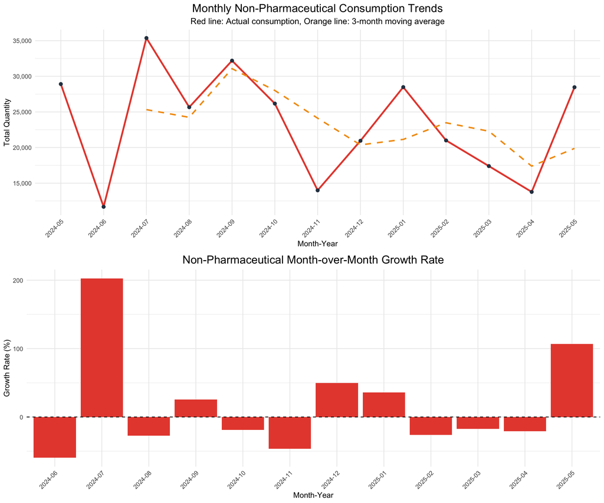